# Introduction to Probability

Probability theory is a discipline rooted deeply in the real world and in mathematics. We use probabilities and statistics to represent integral parts of our lives, whether the chance of rain on the weather app, batting averages for our local baseball teams, or even the success rate of a medical treatment.

Through the language of statistics, one can concisely describe a situation, and make predictions about what's to come. By building on the basic structures of probability laid out in this chapter, we will be able to understand how these probabilities combine. Understanding probability will make us better equipped to calculate these likelihoods and make decisions without taking unnecessary risks.

*A note to the reader: the examples in this text have been designed with the intention that readers follow along. There will be important methods of application and cautionary tips.*

## Probability

We can use probability to measure the likelihood of an event occurring. We define the probability of an event as a proportion of the number of favorable outcomes and the total number of outcomes. This is possible only under the assumption that all outcomes are equally likely. $($The word favorable for statisticians refers to the event you are studying, and is not necessarily a "good" event.$)$ \ Because the number of favorable outcomes is always less than or equal to the total number of outcomes and it is never negative, probability is always between 0 (probability of an impossible event) and 1 (probability of a certain event).

$$ P(A) = \frac{Number~of~Favorable~Outcomes}{Total~Number~of~Outcomes}$$

#### Example 0.

You are drawing items out of a box. In the box is one green tennis ball, one orange tennis ball, and two white golf balls. You are equally likely to pick any of the balls at every draw. What's the probability that:

You pick an orange ball? You pick a golf ball? You pick a ball? You pick a golf ball that is red?

**Solution**

Probability = $\frac{\text{Favorable Outcomes}}{\text{Total Outcomes}}$.

1. There is one orange tennis ball in the box. So, there is only one favorable outcome out of the four total possible outcomes. Therefore, the probability of picking an orange ball = $\frac{1}{4}$
2. Now, there are two favorable outcomes as there are two golf balls, of the four possible outcomes. Thus, the probability of picking a golf ball is $\frac{2}{4} = \frac{1}{2}$
3. We know that there are only balls in the box. Therefore, the event of picking a ball is a certain event. So, the probability of picking a ball $=1$
4. There is no golf ball in the box that is red. Therefore, the event of picking a red golf ball is an impossible event. Thus, the probability $ = 0 $

### Probability of Events Occuring on a Single Trial

Let's say you toss a coin: what's the probability that you get both heads and tails on the same toss? As you very well know, it is not possible for the result of a coin toss to be both heads and tails. These events are called mutually exclusive events. Two or more events are said to be mutually exclusive if they cannot occur at the same time. For mutually exclusive events, the probability of either occurring is the sum of the probabilities of each occurring. The sum of the probabilities of all inclusive events is 1. For example, when you toss a coin, the sum of the probability of getting a head and the probability of getting a tail is 1.

**Laws of Probability**

\begin{align} \sum\limits_{A \in \omega} P(A) &= 1 \ P(A~or~B) &= P(A)+P(B) \end{align}

### Probabilities of Events Occuring on Multiple Trials

#### Example 1.

What's the probability that you get 2 heads when you flip two coins?

**Solution**

The process of calculating the probability of, for example, two events requires counting the favorable outcomes divided by the total outcomes. Observe in Figure 1.1 that the favorable outcome of getting two heads is 1 possibility out of 4 equally likely possibilities.

When probabilities become more complex, we can use simple computations instead. Note that these computations are representations of the possible probabilities used in the table.

\begin{align*} P(2~Heads) &= P(Heads~on~Coin~1) * P(Heads~on~Coin~2) \\ P(2~Heads) &= \frac{1}{2} * \frac{1}{2} \\ P(2~Heads) &= \frac{1}{4} \end{align*}

|  | Heads | Tails |
| --- | --- | --- |
| Heads | 1 | 1 |
| Tails | 1 | 1 |

#### Example 2.

What's the probability that you get one head and one tail when you flip two coins?

## Replacement

When something is done *with* replacement, that means the probability of getting a certain outcome remains unchanged despite having performed the event already. A common example of this phenomenon, which also appears later in the section, is a fair 6-sided die. Even if the die is rolled once and the outcome is a 5, the next roll can still yield a 5 with an equal probability.

### Polling with Replacement

Polling with replacement means that every time when an event happens, it does NOT affect the probability of other independent events. Therefore, the probability of a particular independent event is fixed regardless of previous occurrence of any event. This implies that the same event could possibly occur more than once in one setting.

#### Example 2. Rolling A Die

A fair 6-sided die has numbers from 1 to 6. Each time when a die is rolled, the outcome will be a number from 1 to 6. The probability of getting any of the 6 numbers is the same, which is 1/6. Each roll is independent from other rolls because the previous roll does not affect the outcome of the next roll. Let the probability of getting a 1 be P(A), (P(A) = 1/6) and the probability of getting a 2 be P(B), (P(B) = 1/6).

1. What is the probability of rolling a 1 and a 2 on the same roll? 2. What is the probability of rolling a 1 or a 2 on the same roll? 3. What is the probability of rolling a 1 on the first roll and a 2 on the second roll?

**Solution**

1. The chance of getting both 1 and 2 on the same roll is impossible since the outcome could only be a single number, therefore P(A and B) = 0.
2. The chance of getting either 1 or 2 on the same roll is the sum of P(A) and P(B) because it includes the possibilities of two outcomes out of 6 outcomes in total, which is 1/6 + 1/6 = 2/6. Therefore, P(A or B) = P(A) + P(B).
3. The chance of getting 1 on the first roll(event A) then getting a 2 on the second roll(event B) equals to (1/6) $\times$ (1/6), because in order for event B to occur after event A, there is only one possible way, therefore we multiply P(A) and P(B). The reason why P(B) stays the same after Event A has occurred is that every roll is a poll with replacement--in this case, it can be interpreted as a die has 6 sides or 6 outcomes on every roll regardless of previous results.

Based on the observations we just made in the previous example, we can establish a set of formulas for dealing with the probabilities of two independent events, A and B.

For any two events, $A$, and $B$: $$ P(A \& B) = P(A)P( B | A) = P(B)P(A | B)$$ If the two events are independent, then we have that $P(B \text{ given } A) = P(B) $ and $P(A | B) = P(A)$

#### Example 3.

A die is rolled $3$ times. What is the probability that the face $1$ never appears in any of the rolls?

**Solution** Let's break the question into simpler problems. What is the chance that $1$ does not appear in a single roll?

The possible faces that can appear in a single roll, excluding $1$, are $2,3,4,5, \& 6$. Therefore, probability of not getting $1$ in a single roll of die = $\frac{5}{6} $ \noindent Since we are rolling a die, the chance of not getting $1$ is the same in subsequent rolls. The probability that $1$ does not appear in any of $3$ rolls $= \frac{5}{6} \times \frac{5}{6} \times \frac{5}{6} = (\frac{5}{6})^3 $

#### Example 4.

A die is rolled $100$ times.

What is the chance that only faces $2, 4 \hbox { or } 6$ appear?

**Solution**

Chance that either $2, 4 \hbox { or } 6$ appear in a single roll = $\frac{3}{6} $ \noindent Since we are rolling a die, the chance that either $2, 4 \hbox { or } 6$ appear in a single roll is the same in subsequent rolls. Therefore, chance that only $2, 4 \hbox { or } 6$ appear in $n$ rolls $= (\frac{3}{6})^n = (\frac{1}{2})^n $ }

#### Example 5.

A die is rolled two times. What is the probability that the two rolls had different faces?

What is the probability that the two rolls had different faces?

**Solution** To understand the problem, we can think in the following way: The first roll can be any of $1,2,3,4,5 \hbox{ or } 6$. Hence, we will accept any face for the first roll since all faces are equally favorable. In the second roll, the face should be anything but first roll and thus, it can be any of $5$ different faces.

Probability of getting any of six faces in the first roll$= \frac{6}{6} = 1 $

Probability of getting any face but the face of first roll$= \frac{5}{6} $

Probability that the two rolls had different faces $= \frac{6}{6} \times \frac{5}{6} = \frac{5}{6} $

#### Example 6.

There are $20$ students in a class. A computer program selects a random sample of student by drawing $5$ students at random with replacement. This implies that every student has the same chance to be selected and may be picked on more than one draws.

What is the chance that a particular student is among the $5$ selected students?

**Solution**

Since it is difficult to compute every possible case that includes a particular student, we would look at its complement and see if it is simpler to compute.

Since we are sampling with replacement, probability that a particular student is not selected in a single draw = $(\frac{20-1}{20})$ = $\frac{19}{20} $

Probability that a particular student is not selected in all $5$ draws (which is the entire sample) = $(\frac{19}{20})^5 $

Probability of a particular student getting selected in the sample = 1 - Probability that a particular student is not selected in the sample = $1 - (\frac{19}{20})^5$

**Generalization:**

Total number of students = N Sample size = n

Probability that a particular student is not selected$= (\frac{N-1}{N})^n = (1 - \frac{1}{N})^n$

Probability of a particular student getting selected = 1 - probability that a particular student is not selected = $1 - (1 - \frac{1}{N})^n$

## The Birthday Problem

Parties are great social events, and while mingling in the crowd, you might learn that you share the same favorite color, same car, or perhaps even the same birthday with another person.It may seem strange that, in a room of only perhaps 30 people, you share a birthday with someone else (after all there are 365 possible birthdays), but statistics actually tells us the opposite. This situation is the premise of the birthday problem: What is the minimum number of people that need to be in a room, so there is a fair chance that two share the same birthday?

Some common assumptions that we'll use to make our calculations simpler:

- There are 365 days in every year (We're ignoring leap years).
- There is no 'clumping' i.e. Each child's birthday is equally likely to be on any of the days regardless of others' birthday. For instance, there are no twins in the room.

### Calculating the Probability

The first step in figuring out our problem, is to find the probability of two people sharing a birthday when there are N people.

Let P(A) be the probability that at least two children in the room have the same birthday. In order to compute P(A), it is often easier to compute the complement, that is, P(A') the probability that they do not have the same birthday.

When there are two person in the room, the probability that everyone has different birthdays will be $\frac{364}{365}$. When there are three people, the probability can be defined by the previous probability (with 2 people) and the probability that the third birthday is unique. Thus, the probability can be given by

$$\Rightarrow \frac{364}{365} \times \frac{363}{365}$$

Let's extend the logic to $n$ people, with a table:

[output not shown]

Now that we've found a formula for the probability, let's graph it:

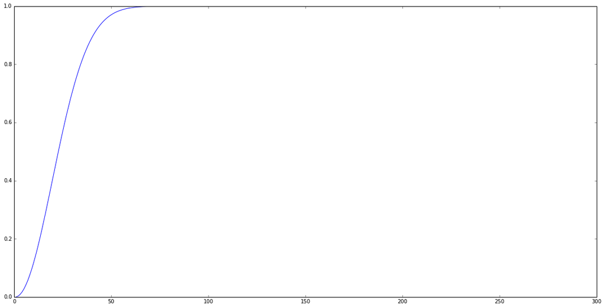

```python
import scipy.misc as misc
p = 1
vals = [(1,0)]
for i in range(2,300):
    p*= (366-i)/365
    vals.append((i,1-p))
plt.figure(figsize=(20,10))
plt.plot(*list(zip(*vals)));
```

```python
%%jsPlot l ['Beginning Range',0,100,5], ['End of Range',10,100,5]

def data(down, up):
    if down >= up:
        down = 0
    p = 1
    x = [1]
    y = [0]
    for i in range(up):
        p *= (366-i)/365
        x.append(i)
        y.append(1-p)
    plot(x[down:],y[down:])
    write("The probability that two people share a birthday in a room with "+str(up)+" people is "+str(y[len(y)-1]))
```

```
l
 ['Beginning Range',0,100,5], ['End of Range',10,100,5]
1
```

[interactive chart not shown]

Wow! The probability spikes up very quickly, and when $n$ is greater than 100 people, the probability is near 1. The reason for this spike-up is the involvement of combinatorics, which causes the probability to increase very fast compared to the increase in the number of people. Our original question was to find the point at which there was a 50% probablity that two people have the same birthday, so let's zoom in, and find where $P(A) = 50\%$.

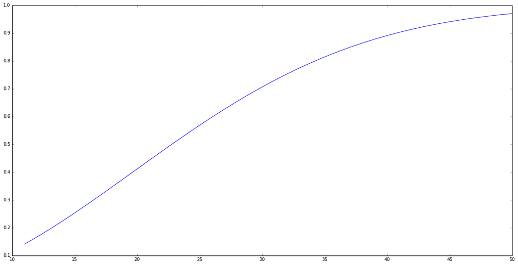

```python
plt.figure(figsize=(20,10))
plt.plot(*list(zip(*vals[10:50])));
```

If you look closely, you can notice that our graph hits halfway, when $n=23$. This is somewhat counterintuitive, but this interesting statistical example only goes to show how powerful probabilities can be when we combine them on a large scale.

## The Gambler's Rule

So far, we've only applied probabilities to small games, finding the chances of events occurring in dice and coin games with a small number of events. Now, we'll combine all the ideas presented to examine the mechanics of a real world gambling scenario. \

#### The Game

Say you are playing a game where $N$ people put in a bet, and one person is chosen at random to win the whole pot. What is the chance that you will win? Using the concepts we have learned from probability with replacement, we can find a good strategy about how we can approach this game.

### Placing Bets

For this application, we will need to define our conditions. For what follows, $N$ and $n$ are integers greater than 1. When you are playing this gambling game $n$ times, you have a chance of winning $\frac{1}{N}$ each time you play. The chance of winning a certain bet is the same no matter what the outcomes of any previous bets were. These are the only conditions needed; they will remain constant.

$$P(Winning~Bet)~=~\frac{1}{N}$$

\noindent From this, we can already conclude that the chance we will lose one bet is $1 - \frac{1}{N}$ because the probability we lose is the chance that we are not able to win.

$$P(Losing~1~Bet)~=~1 - \frac{1}{N}$$

\noindent Knowing the probability we can lose one bet brings us to the next thing we want to find: What is the chance that we will lose $n$ times straight? Let's first figure out the chance we can win $n = 2$ bets. We can figure this out by applying simple rules of probability we have just learned. The probability of getting both results is their probabilities multiplied together, essentially returning a probability of a probability. Our assumptions above tell us that the probability of winning a bet is the same for each bet. No differently, our probability of losing the second bet is the same as our probability of losing the last bet. This gives us:

$$P(Losing~2~bets)~=~(1 - \frac{1}{N})*(1 - \frac{1}{N})$$

\noindent Now, finding the chance that we lose n times straight is simple. If we think of each succeeding bet as a probability of its preceding bet's probability, the probability of losing the next bet is simply the probability of losing the next bet times the probability of losing the previous bets. With our assumptions, we can conclude that:

$$P(Losing~all~n~bets)~=~(1-\frac{1}{N})^n$$

\noindent The final chance we have to find is the chance of winning at least 1 bet out of n bets. At this point, many students will be quite dumbfounded and try to use some other fancy probabilistic method involving combinations or what not, but the answer to this is simple. The opposite of losing all of the bets is winning at least 1 bet. That is it!

$$P(Winning~at~least~1~bet)~=~1-(1-\frac{1}{N})^n$$

### How to Get a Fair Chance?

When you flip a coin, you get a 50\% chance of landing heads and a 50\% chance of landing tails. We say that this is a fair chance as there is no difference in chance between landing either outcome. How many bets do you think it will take to give you a fair chance of winning? Come up with a guess and keep it with you for the end, when we solve the problem. In order to solve for this, we will need to solve for the smallest $n$ for which the chance that you win at least one of the n times is greater than 1/2. Mathematically, we say:

$$\frac{1}{2} < 1-(1 - \frac{1}{N})^n$$$$\frac{1}{2} >~(1 - \frac{1}{N})^n$$

In order to isolate $n$, let's take the logarithm of both sides

$$log\frac{1}{2} > nlog(1 - \frac{1}{N})$$

Since the logarithm is a strictly increasing function, it preserves the inequality $$\frac{log\frac{1}{2}}{log(1 - \frac{1}{N})} <~ n$$ Remember that we must flip the inequality because $log(1-\frac{1}{N})$ is negative!} $$n >\frac{log\frac{1}{2}}{log(1 - \frac{1}{N})}$$

We've now come up with a solution to our original problem, although it doesn't really give us a good understanding of how large this value is. So, let's try to approximate it. To help us solve our problem, we'll find the value of $log(1 - x)$ for small, positive x. We know that the log of numbers close to 1 is close to zero (Recall that log(1) = 0). We will take a small side track and prove this before we move on.

Let us draw a graph of the function f(x)= log(x) along with its tangent line at x = 1.

Now, for a small positive x, plot and label the three following points on this graph:

A: ((1-x),0) B: ((1-x), log(1-x)) C: (1,0)

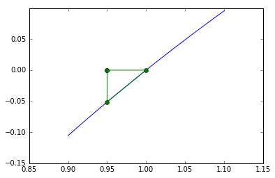

```python
x = np.linspace(.9,1.1,100)
y = np.log(x)
diff = .05
newPoints = [(1-diff,0),(1-diff, np.log(1-diff)),(1,0),(1-diff,0)]
plt.plot(x,y)
plt.plot(*list(zip(*newPoints)),marker="o");
```

```python
%%jsPlot l ['x',0,.4,.01]

def linspace(start,end,num):
    spacing = (end-start)/num
    return [start+spacing*i for i in range(num)]

def data(off):
    x = linspace(1-3*off,1+3*off,100)
    y = [math.log(i) for i in x]
    xp = [1-off,1-off,1]
    yp = [math.log(1-off),off/-1000,off/-1000]
    plot(x,y)
    plot(xp,yp)
    angle = math.atan(math.log(1-off)/-off)*180/math.PI
    write("The angle is " +angle.toFixed(3)+ " degrees")
    write("The slope of the line is "+(1/(1-off)))
```

```
l
 ['x',0,.4,.01]
2
```

[interactive chart not shown]

Do you notice something about these plots? They produce a triangle! Not just any triangle, but a 45-45 right triangle. Using our knowledge of 45-45 right triangles, solve for the distance from 1 to point A. The two sides of the triangle are both x. Therefore, the distance from log(1) to point A, which is log(1-x) closely approximates to x (Recall that distances are always positive). This means that:

Now that we know that the approximation for log(1-x) is about -x itself for small, positive values of x, we can proceed to our proof.

Let's plug that into our equation:

$$\frac{log\frac{1}{2}}{log(1-\frac{1}{N})}~<~ n$$

Since we are assuming that $N$ is large, we can likewise say that $\frac{1}{N}$ is very small, so we can make our substitution $$\frac{log\frac{1}{2}}{-\frac{1}{N}}~<~ n$$ All that remains now is simplification $$-Nlog\frac{1}{2} ~<~ n $$ $$-N(log(1) - log(2)) ~<~ n$$ $$-N(-log(2)) ~<~ n$$ $$Nlog2 ~<~ n$$ $\log(2)$ is approximately equal to 2/3, so we can now say: $$n \gtrsim \frac{2}{3} N$$

Gamblers have know for centuries that the answer to the question we posed is about 2/3 of N. Plug large numbers into this equation. You will soon realize that you need an absurdly large number to get a fair chance. You need 2/3 of a million bets as a matter of fact! Was this close to your guess?